# Chemistry with Qubits

# 1) Creating the Qubit Hamiltonian

The qubit hamiltonian is of the form:

$$ \mathcal{H} = \sum_{p,q=1}^N t_{pq} c^\dagger_p c_q + \sum_{p,q,r,s=1}^N u_{pqrs} c^\dagger_p c^\dagger_q c_r c_s $$

Thus we need to calculate $t_{pq}$, $u_{pqrs}$ and the fermionic operators.

## 1.1) Calculating the integrals

In order to create the qubit hamiltonian, we need to calculate the one- and two-body integrals this is done in using `PySCFDriver`. For creating the Qubit Hamiltonian we need three quantities:

- Basis
- Molecule
- Coordinates

Another important quantity that we need to get is the nuclear repulsion energy that will be subtracted from the energy that we find using VQE.

```python
import numpy as np
import matplotlib.pyplot as plt
from qiskit.chemistry.drivers import PySCFDriver, UnitsType

molecular_coordinates = 'Li 0 0 0; H 1.6 0 0'
distance_unit = UnitsType.ANGSTROM
basis = 'sto3g'

driver = PySCFDriver(molecular_coordinates, unit=distance_unit)

molecule = driver.run()

h1 = molecule.one_body_integrals
h2 = molecule.two_body_integrals
nuclear_repulsion_energy = molecule.nuclear_repulsion_energy
```

## 1.2) Creating the fermionic operator

To create the fermionic operator we use the one- and two-body integrals that we calculated before and use the `FermionicOperator` class from qiskit.

```python
from qiskit.chemistry import FermionicOperator

ferOp = FermionicOperator(h1=h1, h2=h2)

num_spin_orbitals = molecule.num_orbitals * 2
num_particles = molecule.num_alpha + molecule.num_beta

freeze_list = [0]
remove_list = [-3, -2]

# Convert all negative idx to positive
remove_list = [x % molecule.num_orbitals for x in remove_list]
freeze_list = [x % molecule.num_orbitals for x in freeze_list]
remove_list = [x - len(freeze_list) for x in remove_list]

# Update the idx in remove_list of the idx after frozen,
# since the idx of orbitals are changed after freezing

remove_list += [x + molecule.num_orbitals - len(freeze_list)  for x in remove_list]
freeze_list += [x + molecule.num_orbitals for x in freeze_list]
```

We can reduce the number of qubits, freezing some of the modes which will always be full.

```python
ferOp_f, energy_shift = ferOp.fermion_mode_freezing(freeze_list)

num_spin_orbitals -= len(freeze_list)
num_particles -= len(freeze_list)
```

We can also remove some of the orbitals which the energy would be too high for the ground state, and thus would not be accessed.

```python
ferOp_fr = ferOp_f.fermion_mode_elimination(remove_list)
num_spin_orbitals -= len(remove_list)
```

## 1.3) Qubit operator

Now we need to choose a mapping to convert the Fermionic operator into a qubit operator, we shall use the parity mapping, but other mappings such as Bravyi-Kitaev or Jordan-Wigner.

```python
map_type = 'parity'
qubitOp = ferOp_fr.mapping(map_type=map_type)
print(qubitOp)
```

```
Representation: paulis, qubits: 6, size: 118
```

```python
print("Example of Pauli Strings:")
print(qubitOp.print_details()[0: 232])
```

```
Example of Pauli Strings:
IIIIII	(-0.20765933501971037+0j)
IIIIIZ	(-0.040016509101633395+0j)
IIIIZX	(-0.00031512637665464215+0j)
IIIIIX	(0.00031512637665464215+0j)
IIIZXX	(0.0067075528892923+0j)
IIIIYY	(0.0067075528892923+0j)
IIIIZZ	(-0.12914560136887676+0j)
I
```

Let's search for Z2 Symmetries on our qubit opperators:

```python
from qiskit.aqua.operators import Z2Symmetries
pauli_symm = Z2Symmetries.find_Z2_symmetries(qubitOp)
print(pauli_symm)
```

```
Z2 symmetries:
Symmetries:
IIIZII
ZIIIII
Single-Qubit Pauli X:
IIIXII
XIIIII
Cliffords:
IIIZII	(0.7071067811865475+0j)
IIIXII	(0.7071067811865475+0j)

ZIIIII	(0.7071067811865475+0j)
XIIIII	(0.7071067811865475+0j)

Qubit index:
[2, 5]
Tapering values:
  - Possible values: [1, 1], [1, -1], [-1, 1], [-1, -1]
```

By this we remove the 1st and last Z2 Symmetries, because we know that they are about the number of particles in the Alpha and Beta zones.

```python
qubitOp_t = Z2Symmetries.two_qubit_reduction(qubitOp, num_particles)

print(qubitOp_t)
```

```
Representation: paulis, qubits: 4, size: 100
```

Let's see if there is any symmetries left

```python
pauli_symm2 = Z2Symmetries.find_Z2_symmetries(qubitOp_t)
print(pauli_symm2)
```

```
Z2 symmetries:
Symmetries:
Single-Qubit Pauli X:
Cliffords:
Qubit index:
[]
Tapering values:
  - Possible values: []
```

Solving the operator exactly we have the smallest eigenvalue:

```python
import warnings
warnings.filterwarnings("ignore")

from qiskit.aqua.algorithms import ExactEigensolver

def exact_solver(qubitOp):
    ee = ExactEigensolver(qubitOp)
    result = ee.run()
    ref = result['energy']
    # print('Reference value: {}'.format(ref))
    return ref

ref = exact_solver(qubitOp_t)
print(f'Exact energy is: {np.round(ref,4)}')
```

```
Exact energy is: -1.0771
```

# 2) Applying the VQE for finding the ground state

## 2.1) Running on a ideal device

Running on an ideal device we do not need to worry about decoherence and the coupling mapping, thus I shall use the best possible ansatz which is the UCCSD, this will show us that this ansatz is impossible to work on current devices.

For the UCCSD we usually choose the initial state to be the Hartree-Fock solution which can be calculated efficiently on a classical computer.

```python
from qiskit.aqua import QuantumInstance
from qiskit.aqua.algorithms import VQE
```

```python
from qiskit import BasicAer
backend = BasicAer.get_backend("statevector_simulator")
```

```python
from qiskit.chemistry.components.variational_forms import UCCSD
from qiskit.chemistry.components.initial_states import HartreeFock

initial_state = HartreeFock(num_spin_orbitals,
        num_particles,
        qubit_mapping='parity')

var_form = UCCSD(
        num_orbitals=num_spin_orbitals,
        num_particles=num_particles,
        initial_state=initial_state,
        qubit_mapping='parity')
```

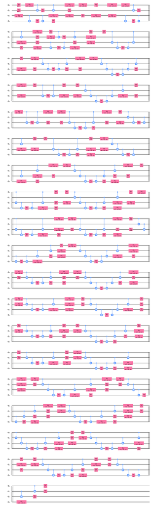

```python
var_form.construct_circuit([0.]*var_form.num_parameters).decompose().draw('mpl')
```

```python
print(f"Circuit depth: {var_form.construct_circuit([0.]*var_form.num_parameters).decompose().depth()}")
```

```
Circuit depth: 275
```

In order to run the VQE we should choose a classical optimizer, in this case we shall use the COBYLA optimizer.

```python
from qiskit.aqua.components.optimizers import COBYLA
optimizer = COBYLA()
```

Let's initialize our VQE, and run on an ideal device:

```python
vqe = VQE(operator=qubitOp_t,
          var_form=var_form,
          optimizer=optimizer)
```

```python
from qiskit import Aer
result = vqe.run(QuantumInstance(Aer.get_backend('statevector_simulator')))
```

```python
def error(predicted_value, real_value):
    return np.abs(predicted_value - real_value)

print('Error:', error(result['eigenvalue'], ref))
```

```
Error: 7.826323589199546e-09
```

## 2.2) Running on a Noisy Device

Now that we are running on a noisy device with limited connection, we should use a more efficient ansatz

Let's define our noise model based on the `ibmq_valencia` chip which is a quantum computer with QV16 and 5 qubits.

```python
from qiskit import IBMQ
provider = IBMQ.load_account()
```

```python
from qiskit.providers.aer import noise
chip_name = 'ibmq_valencia'
device = provider.get_backend(chip_name)
coupling_map = device.configuration().coupling_map
noise_model = noise.device.basic_device_noise_model(device.properties())
basis_gates = noise_model.basis_gates
```

Let's see the coupling map of the device:

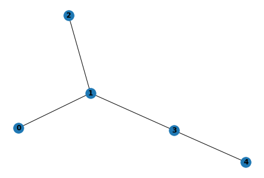

```python
import networkx as nx
G = nx.Graph()
G.add_edges_from(coupling_map)
nx.draw(G, with_labels=True, font_weight='bold')
```

For a hardware-efficient ansatz we choose the RYRZ with CX as entangling gates.

```python
from qiskit.circuit.library import TwoLocal
ent_map = [(i,j) for i,j in coupling_map if i != 4 and j != 4]
var_form = TwoLocal(qubitOp_t.num_qubits, ['ry','rz'], 'cx', ent_map, reps=2)
```

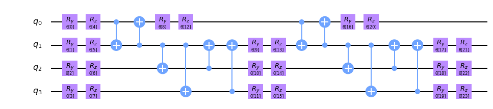

```python
var_form.draw('mpl')
```

Running on the noisy device:

```python
optimizer = COBYLA()
```

```python
vqe = VQE(qubitOp_t,
          var_form,
          optimizer)
```

```python
backend = Aer.get_backend("qasm_simulator")
quantum_instance = QuantumInstance(backend=backend,
                                   shots=1000,
                                   noise_model=noise_model,
                                   coupling_map=coupling_map,
                                   basis_gates=basis_gates,)
```

```python
vqe_result = np.real(vqe.run(backend)['eigenvalue'])
```

```python
print('Error:', error(vqe_result, ref))
```

```
Error: 0.0012911464789935323
```

# Dissociation plot

Using VQE and varying the distance we can have the dissociation plot of the LiH molecule.

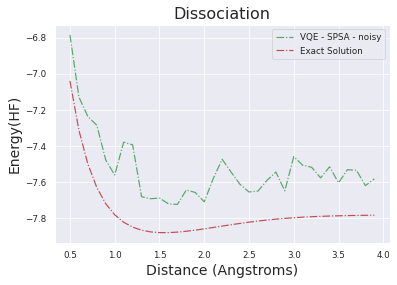

# References:

- [Qiskit Textbook](https://qiskit.org/textbook/ch-applications/vqe-molecules.html)
- [Quantum Computing: An applied Approach - Hidary](https://www.springer.com/gp/book/9783030239213)
- [Qiskit Global Summer School](https://www.youtube.com/watch?v=Rs2TzarBX5I&list=PLOFEBzvs-VvrXTMy5Y2IqmSaUjfnhvBHR)

```python
import qiskit.tools.jupyter
%qiskit_version_table
```

Version Information

| Qiskit Software | Version |
| --- | --- |
| Qiskit | 0.19.1 |
| Terra | 0.14.1 |
| Aer | 0.5.1 |
| Ignis | 0.3.0 |
| Aqua | 0.7.0 |
| IBM Q Provider | 0.7.0 |
| System information |  |
| Python | 3.7.3 \| packaged by conda-forge \| (default, Jul 1 2019, 21:52:21) [GCC 7.3.0] |
| OS | Linux |
| CPUs | 2 |
| Memory (Gb) | 7.664035797119141 |
| Wed Oct 14 16:20:35 2020 -03 |  |